# EE658/758 Machine Learning in Engineering

## Assignment-2: Logistic Regression

```python
!pip install mlxtend
```

```python
import os
import numpy as np
import pandas as pd

import seaborn as sns
import matplotlib.pyplot as plt


from sklearn.preprocessing import StandardScaler
from sklearn.linear_model import LogisticRegression
from sklearn.model_selection import train_test_split
from mlxtend.plotting import plot_decision_regions
from sklearn.decomposition import PCA

from sklearn.metrics import accuracy_score, classification_report, confusion_matrix, f1_score
```

```python
df = pd.read_csv(r'data.csv')

df.head()
```

|  | -6 | 592 | 0 |
| --- | --- | --- | --- |
| 0 | -5 | 807 | 0 |
| 1 | -5 | -344 | 0 |
| 2 | -5 | -126 | 0 |
| 3 | -5 | 243 | 0 |
| 4 | -5 | 185 | 0 |

```python
df.describe()
```

|  | -6 | 592 | 0 |
| --- | --- | --- | --- |
| count | 199.000000 | 199.000000 | 199.000000 |
| mean | 0.964824 | 325.477387 | 0.582915 |
| std | 3.636761 | 286.265167 | 0.494321 |
| min | -5.000000 | -445.000000 | 0.000000 |
| 25% | -2.000000 | 152.500000 | 0.000000 |
| 50% | 1.000000 | 349.000000 | 1.000000 |
| 75% | 4.000000 | 538.000000 | 1.000000 |
| max | 8.000000 | 1056.000000 | 1.000000 |

```python
df.info()
```

```
<class 'pandas.core.frame.DataFrame'>
RangeIndex: 199 entries, 0 to 198
Data columns (total 3 columns):
 #   Column  Non-Null Count  Dtype
---  ------  --------------  -----
 0   -6      199 non-null    int64
 1   592     199 non-null    int64
 2   0       199 non-null    int64
dtypes: int64(3)
memory usage: 4.8 KB
```

```python
columns = ['Feature1', 'Feature2', 'Label']

df.columns = columns

df.head()
```

|  | Feature1 | Feature2 | Label |
| --- | --- | --- | --- |
| 0 | -5 | 807 | 0 |
| 1 | -5 | -344 | 0 |
| 2 | -5 | -126 | 0 |
| 3 | -5 | 243 | 0 |
| 4 | -5 | 185 | 0 |

### Part A: Logistic Regression with Scikit-learn

- **Load the dataset and split it into training and testing subsets.**
- **Use the scikit-learn library to develop a logistic regression model based on the training data. Use only Feature1 and Feature2.**
- **Plot the data points and the decision boundary of the model.**
- **Evaluate the model on the testing data and report its accuracy.**

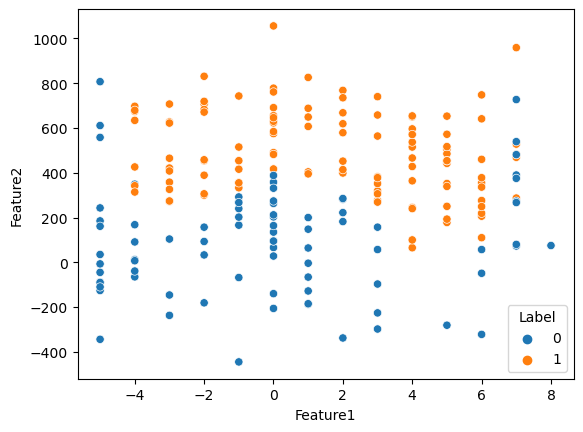

```python
sns.scatterplot(data=df, x='Feature1', y='Feature2', hue='Label')
```

```python
X = df[['Feature1', 'Feature2']]
Y = df['Label']


X_train, X_test, y_train, y_test = train_test_split(X, Y, test_size=0.20, random_state=42)
```

```python
classifier = LogisticRegression()

classifier.fit(X_train, y_train)

pred = classifier.predict(X_test)
```

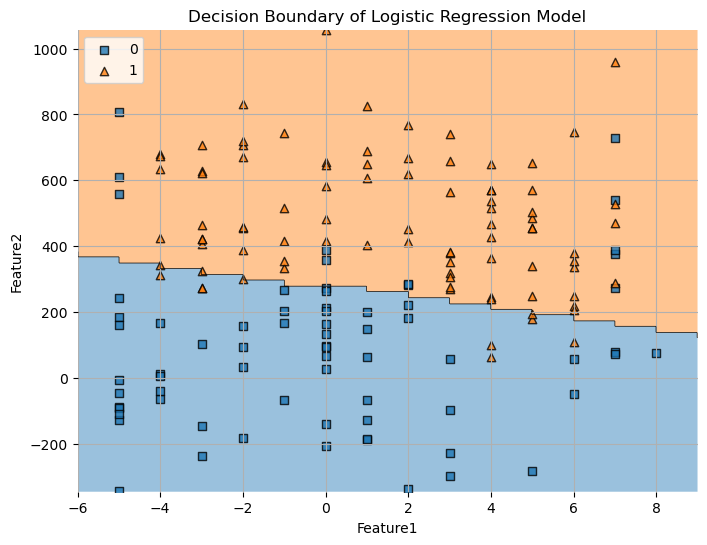

```python
# Plot decision boundary
plt.figure(figsize=(8, 6))
plot_decision_regions(X_train.values, y_train.values, clf=classifier, legend=2)

# Adding axes annotations
plt.xlabel('Feature1')
plt.ylabel('Feature2')
plt.title('Decision Boundary of Logistic Regression Model')
plt.legend(loc='upper left')
plt.grid(True)
plt.show()
```

```python
print(f"Accuracy on test set is: {accuracy_score(y_test, pred)*100}")

print(f"F1 Score of test set is: {f1_score(y_test, pred)*100}")

print(classification_report(y_test, pred))
```

```
Accuracy on test set is: 90.0
F1 Score of test set is: 92.85714285714286
              precision    recall  f1-score   support

           0       0.91      0.77      0.83        13
           1       0.90      0.96      0.93        27

    accuracy                           0.90        40
   macro avg       0.90      0.87      0.88        40
weighted avg       0.90      0.90      0.90        40
```

### Part B: Logistic Regression Without Scikit-learn

- **Implement logistic regression from scratch.**
- **Use the same training and testing data splits as in Part A.**
- **Develop a logistic regression model based on the training data, using only Feature1 and Feature2**
- **Display the cost (loss) as a function of iterations during the training process.**
- **Plot the data points and the decision boundary of your model**
- **Evaluate the model on the testing data and report its accuracy.**

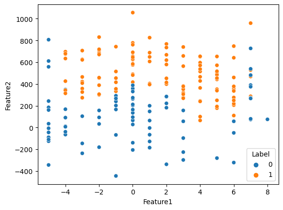

```python
sns.scatterplot(data=df, x='Feature1', y='Feature2', hue='Label')
```

```python
X_train_array = X_train.to_numpy()
y_train_array = y_train.to_numpy()

X_test_array = X_test.to_numpy()
y_test_array = y_test.to_numpy()

# Scale X_train_array
scaler = StandardScaler()
X_train_scaled = scaler.fit_transform(X_train_array)
X_test_scaled = scaler.transform(X_test_array)

N, D = X_train_scaled.shape

# randomly initialize the weights
w = np.random.randn(D)

# Sigmoid function remains the same
def sigmoid(z):
    return 1 / (1 + np.exp(-z))

# Improved cross-entropy function
def cross_entropy(T, Y):
    return -np.sum(T * np.log(Y) + (1 - T) * np.log(1 - Y))

# Use scaled X_train in computations
Y = sigmoid(X_train_scaled.dot(w))


costs = []
learning_rate = 0.01  # Try a smaller learning rate
for i in range(100):
    if i % 10 == 0:
        loss = cross_entropy(y_train_array, Y)
        print(loss)
        costs.append(loss)

    # gradient descent weight update
    w += learning_rate * X_train_scaled.T.dot(y_train_array - Y)

    # recalculate Y
    Y = sigmoid(X_train_scaled.dot(w))

print("Final Weights (w) obtained are: ", w)


predictions = sigmoid(X_test_scaled.dot(w))
```

```
154.65976878993723
62.96720380928694
62.259373483699214
62.16438756338174
62.142677193471656
62.137276920512775
62.13588932045252
62.13552714258145
62.13543186222692
62.13540669541844
Final Weights (w) obtained are:  [0.58706618 2.42899416]
```

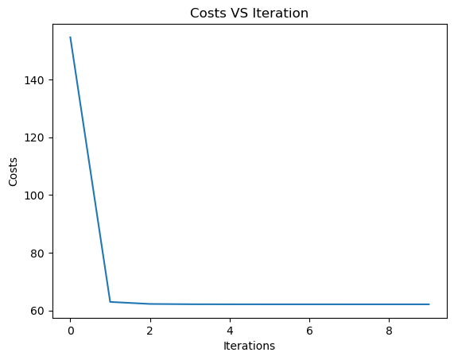

```python
plt.plot(range(len(costs)), costs)
plt.xlabel("Iterations")
plt.ylabel("Costs")
plt.title("Costs VS Iteration")
plt.show()
```

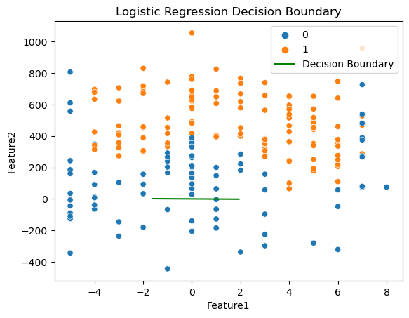

```python
def plot_decision_boundary(X, y, w):
    sns.scatterplot(data=df, x='Feature1', y='Feature2', hue='Label')

    # Plot decision boundary
    if X.shape[1] == 2:  # If there are only two features
        x1 = np.linspace(np.min(X[:,0]), np.max(X[:,0]), 100)
        x2 = -(w[0] + w[1]*x1) / w[1]  # Decision boundary: w0 + w1*x1 + w2*x2 = 0 => x2 = -(w0 + w1*x1) / w2
        plt.plot(x1, x2, color='green', label='Decision Boundary')
    else:
        x1_min, x1_max = np.min(X[:, 1]), np.max(X[:, 1])
        x2_min, x2_max = np.min(X[:, 2]), np.max(X[:, 2])
        xx1, xx2 = np.meshgrid(np.linspace(x1_min, x1_max), np.linspace(x2_min, x2_max))
        X_new = np.c_[np.ones((xx1.ravel().shape[0], 1)), xx1.ravel(), xx2.ravel()]
        zz = X_new.dot(w)
        yy = sigmoid(zz)
        yy = yy.reshape(xx1.shape)
        plt.contour(xx1, xx2, yy, levels=[0.5], cmap='Greens', alpha=0.5, linestyles=['-'])

    plt.xlabel('Feature1')
    plt.ylabel('Feature2')
    plt.title('Logistic Regression Decision Boundary')
    plt.legend()
    plt.show()



# Plot the decision boundary
plot_decision_boundary(X_train_scaled, y_train_array, w)
```

```python
predictions = np.round(predictions)

print(f"Accuracy on test set is: {accuracy_score(y_test_array, predictions)*100}")

print(f"F1 Score of test set is: {f1_score(y_test_array, predictions, average='weighted')*100}")

print(classification_report(y_test_array, predictions))
```

```
Accuracy on test set is: 87.5
F1 Score of test set is: 87.36363636363636
              precision    recall  f1-score   support

           0       0.83      0.77      0.80        13
           1       0.89      0.93      0.91        27

    accuracy                           0.88        40
   macro avg       0.86      0.85      0.85        40
weighted avg       0.87      0.88      0.87        40
```

```python
predictions
```

```
array([1., 0., 1., 0., 1., 1., 0., 1., 1., 1., 1., 1., 0., 0., 1., 1., 0.,
       1., 1., 1., 0., 1., 1., 1., 0., 1., 1., 0., 1., 0., 1., 1., 1., 1.,
       0., 0., 1., 1., 1., 1.])
```

### Part C: Logistic Regression with Feature Engineering (Scikit-learn)

- **Enhance your dataset by adding new features that are at a higher degree of one of the original features (e.g., Feature1^2, Feature1 * Feature2).**
- **Use the scikit-learn library to develop a logistic regression model based on the enhanced training data.**
- **Plot the data points and the decision boundary of the model.**
- **Evaluate the model on the testing data and report its accuracy.**

```python
df['Feature_Product'] = df['Feature1'] * df['Feature2']
df['Feature_Product_Squared'] = df['Feature_Product'] ** 2
df['Feature_Product_Cubed'] = df['Feature_Product'] ** 3

# Update X with the new features
X = df[['Feature1', 'Feature2', 'Feature_Product', 'Feature_Product_Squared', 'Feature_Product_Cubed']]
Y = df["Label"]
# Split the data into training and testing sets
X_train, X_test, y_train, y_test = train_test_split(X, Y, test_size=0.20, random_state=42)
```

```python
classifier = LogisticRegression()

classifier.fit(X_train, y_train)

pred = classifier.predict(X_test)
```

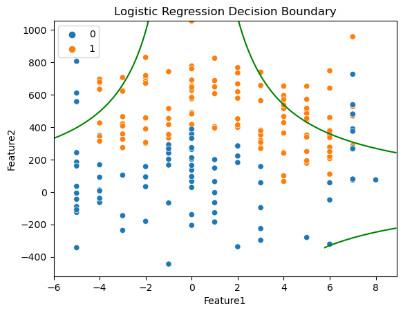

```python
# Function to plot the decision boundary
def plot_decision_boundary(X, y, model):
    sns.scatterplot(data=df, x='Feature1', y='Feature2', hue='Label')

    # Generate a grid of points
    x1_min, x1_max = X['Feature1'].min() - 1, X['Feature1'].max() + 1
    x2_min, x2_max = X['Feature2'].min() - 1, X['Feature2'].max() + 1
    xx1, xx2 = np.meshgrid(np.arange(x1_min, x1_max, 0.1), np.arange(x2_min, x2_max, 0.1))

    # Flatten grid to apply the model
    grid = np.c_[xx1.ravel(), xx2.ravel()]
    if 'Feature_Product' in X.columns:
        grid = np.c_[grid, (grid[:, 0] * grid[:, 1])]
    if 'Feature_Product_Squared' in X.columns:
        grid = np.c_[grid, (grid[:, 0] * grid[:, 1])**2]
    if 'Feature_Product_Cubed' in X.columns:
        grid = np.c_[grid, (grid[:, 0] * grid[:, 1])**3]

    # Compute predictions
    if hasattr(model, 'decision_function'):
        Z = model.decision_function(grid)
    else:
        Z = model.predict_proba(grid)[:, 1]

    # Reshape predictions to match the shape of the meshgrid
    Z = Z.reshape(xx1.shape)

    # Plot decision boundary
    plt.contour(xx1, xx2, Z, levels=[0.5], colors='green', linestyles=['-'])

    # Set plot labels and legend
    plt.xlabel('Feature1')
    plt.ylabel('Feature2')
    plt.title('Logistic Regression Decision Boundary')
    plt.legend()
    plt.show()


plot_decision_boundary(X_train, y_train, classifier)
```

```python
print(f"Accuracy on test set is: {accuracy_score(y_test, pred)*100}")

print(f"F1 Score of test set is: {f1_score(y_test, pred)*100}")

print(classification_report(y_test, pred))
```

```
Accuracy on test set is: 67.5
F1 Score of test set is: 80.59701492537313
              precision    recall  f1-score   support

           0       0.00      0.00      0.00        13
           1       0.68      1.00      0.81        27

    accuracy                           0.68        40
   macro avg       0.34      0.50      0.40        40
weighted avg       0.46      0.68      0.54        40
```

### Part D: Logistiic Regression with Feature Engineering (Without Scikit-learn)

- **Use the enhanced dataset from Part C.**
- **Implement logistic regression from scratch to develop a model based on the enhanced training data.**
- **Display the cost (loss) as a function of iterations during the training process.**
- **Plot the data points and the decision boundary of your model.**
- **Evaluate the model on the testing data and report its accuracy.**

```python
X_train_array = X_train.to_numpy()
y_train_array = y_train.to_numpy()

X_test_array = X_test.to_numpy()
y_test_array = y_test.to_numpy()

# Scale X_train_array
scaler = StandardScaler()
X_train_scaled = scaler.fit_transform(X_train_array)
X_test_scaled = scaler.transform(X_test_array)

N, D = X_train_scaled.shape

# randomly initialize the weights
w = np.random.randn(D)

# Sigmoid function remains the same
def sigmoid(z):
    return 1 / (1 + np.exp(-z))

# Improved cross-entropy function
def cross_entropy(T, Y):
    return -np.sum(T * np.log(Y) + (1 - T) * np.log(1 - Y))

# Use scaled X_train in computations
Y = sigmoid(X_train_scaled.dot(w))

costs = []
learning_rate = 0.01  # Try a smaller learning rate
for i in range(150):
    if i % 10 == 0:
        loss = cross_entropy(y_train_array, Y)
        print(loss)
        costs.append(loss)

    # gradient descent weight update
    w += learning_rate * X_train_scaled.T.dot(y_train_array - Y)

    # recalculate Y
    Y = sigmoid(X_train_scaled.dot(w))

print("Final Weights (w) obtained are: ", w)


predictions = sigmoid(X_test_scaled.dot(w))
```

```
147.85663968823803
61.26375452449892
54.37515441731628
51.56433801565642
49.85115508430349
48.66693947642351
47.78931406802538
47.10761814126094
46.56025269511572
46.11009219052173
45.73325377917887
45.41351449760752
45.139347270498874
44.902254646632045
44.69578286735887
Final Weights (w) obtained are:  [ 1.32721581  4.68152684 -0.64533164 -2.57691158  1.19674434]
```

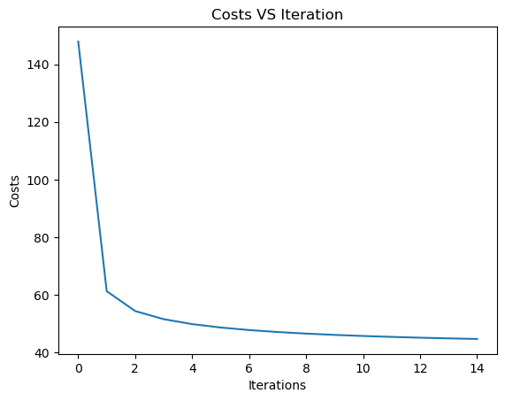

```python
plt.plot(range(len(costs)), costs)
plt.xlabel("Iterations")
plt.ylabel("Costs")
plt.title("Costs VS Iteration")
plt.show()
```

```python
costs
```

```
[147.85663968823803,
 61.26375452449892,
 54.37515441731628,
 51.56433801565642,
 49.85115508430349,
 48.66693947642351,
 47.78931406802538,
 47.10761814126094,
 46.56025269511572,
 46.11009219052173,
 45.73325377917887,
 45.41351449760752,
 45.139347270498874,
 44.902254646632045,
 44.69578286735887]
```

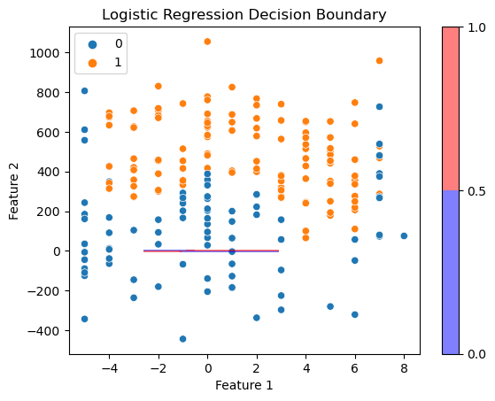

```python
def plot_decision_boundary(X, y, weights):
    # Assuming X is a numpy array and y is the labels array
    sns.scatterplot(data=df, x='Feature1', y='Feature2', hue='Label')

    # Generate a grid of points with a distance of 0.1
    x1_min, x1_max = X[:, 0].min() - 1, X[:, 0].max() + 1
    x2_min, x2_max = X[:, 1].min() - 1, X[:, 1].max() + 1
    xx1, xx2 = np.meshgrid(np.arange(x1_min, x1_max, 0.1),
                           np.arange(x2_min, x2_max, 0.1))

    # Flatten the grid to pass into model
    grid = np.c_[xx1.ravel(), xx2.ravel()]

    # Assuming the model includes polynomial features, you need to recreate them here
    # Adjust these lines to match the features your model uses
    grid_with_features = np.c_[grid,
                               grid[:, 0] * grid[:, 1],  # Feature_Product
                               (grid[:, 0] * grid[:, 1])**2,  # Feature_Product_Squared
                               (grid[:, 0] * grid[:, 1])**3]  # Feature_Product_Cubed

    # Compute predictions using the sigmoid function and weights
    Z = sigmoid(np.dot(grid_with_features, weights))

    # Reshape the result to match xx1 and xx2
    Z = Z.reshape(xx1.shape)

    # Plot the decision boundary
    plt.contourf(xx1, xx2, Z, levels=[0, 0.5, 1], alpha=0.5, colors=['blue', 'red'])
    plt.colorbar()

    # Set plot labels and legend
    plt.xlabel('Feature 1')
    plt.ylabel('Feature 2')
    plt.title('Logistic Regression Decision Boundary')
    plt.legend()
    plt.show()


plot_decision_boundary(X_train_scaled, y_train_array, w)
```

```python
predictions = np.round(predictions)

print(f"Accuracy on test set is: {accuracy_score(y_test_array, predictions)*100}")

print(f"F1 Score of test set is: {f1_score(y_test_array, predictions, average='weighted')*100}")

print(classification_report(y_test_array, predictions))
```

```
Accuracy on test set is: 87.5
F1 Score of test set is: 86.54156577885391
              precision    recall  f1-score   support

           0       1.00      0.62      0.76        13
           1       0.84      1.00      0.92        27

    accuracy                           0.88        40
   macro avg       0.92      0.81      0.84        40
weighted avg       0.89      0.88      0.87        40
```